# An Analysis of Red Wine

Guy Bourne

28 November 2017

*Built with R 3.4.2*

## Introduction

Let me start with a disclaimer, I drink more wine than I should and less than I would like. Since moving to Australia, I have been spoilt for choice with a range of fantastic Aussie wines and when I realised that I had the opportunity to understand a little more about them whilst learning some new skills, well who could resist?

> *“After the first glass, you see things as you wish they were. After the second, you see things as they are not. Finally, you see things as they really are, and that is the most horrible thing in the world.”* **Oscar Wilde**

Given Oscar Wilde’s warning, this analysis will be conducted sober, but the hope is that we will see the world of Red Wine as it really is, and that it won’t be all that bad, plus we’ll have some fun getting there.

Note that throughout this document, I’ll be experimenting with different aesthetics, so I am not aiming for consistency across plots; this would drive me crazy as a reviewer so apologies upfront!

We’ll be exploring the measurable aspects of red wine and seeing how they interact, looking for relationships, whilst also seeing how they relate to critics score of 1 - 10. Note that the id variable X has been converted into a factor prior to analysis.

## Initial Univariate analysis

We’ll start by summarising the dataset and producing a broad spectrum of plots to introduce the data.

```
## 'data.frame':    1599 obs. of  13 variables:
##  $ X                   : Factor w/ 1599 levels "1","2","3","4",..: 1 2 3 4 5 6 7 8 9 10 ...
##  $ fixed.acidity       : num  7.4 7.8 7.8 11.2 7.4 7.4 7.9 7.3 7.8 7.5 ...
##  $ volatile.acidity    : num  0.7 0.88 0.76 0.28 0.7 0.66 0.6 0.65 0.58 0.5 ...
##  $ citric.acid         : num  0 0 0.04 0.56 0 0 0.06 0 0.02 0.36 ...
##  $ residual.sugar      : num  1.9 2.6 2.3 1.9 1.9 1.8 1.6 1.2 2 6.1 ...
##  $ chlorides           : num  0.076 0.098 0.092 0.075 0.076 0.075 0.069 0.065 0.073 0.071 ...
##  $ free.sulfur.dioxide : num  11 25 15 17 11 13 15 15 9 17 ...
##  $ total.sulfur.dioxide: num  34 67 54 60 34 40 59 21 18 102 ...
##  $ density             : num  0.998 0.997 0.997 0.998 0.998 ...
##  $ pH                  : num  3.51 3.2 3.26 3.16 3.51 3.51 3.3 3.39 3.36 3.35 ...
##  $ sulphates           : num  0.56 0.68 0.65 0.58 0.56 0.56 0.46 0.47 0.57 0.8 ...
##  $ alcohol             : num  9.4 9.8 9.8 9.8 9.4 9.4 9.4 10 9.5 10.5 ...
##  $ quality             : int  5 5 5 6 5 5 5 7 7 5 ...
```

Firstly, we note that there are no categorical variables in this dataset. This may limit my ability to learn more about R plotting, however I think that we’ll be able to create some categorical buckets later to make sure that we can add some extra dimensions to plots.

|  | Min. | 1st Qu. | Median | Mean | 3rd Qu. | Max. |
| --- | --- | --- | --- | --- | --- | --- |
| alcohol | 8.40000 | 9.5000 | 10.20000 | 10.4229831 | 11.100000 | 14.90000 |
| chlorides | 0.01200 | 0.0700 | 0.07900 | 0.0874665 | 0.090000 | 0.61100 |
| citric.acid | 0.00000 | 0.0900 | 0.26000 | 0.2709756 | 0.420000 | 1.00000 |
| density | 0.99007 | 0.9956 | 0.99675 | 0.9967467 | 0.997835 | 1.00369 |
| fixed.acidity | 4.60000 | 7.1000 | 7.90000 | 8.3196373 | 9.200000 | 15.90000 |
| free.sulfur.dioxide | 1.00000 | 7.0000 | 14.00000 | 15.8749218 | 21.000000 | 72.00000 |
| pH | 2.74000 | 3.2100 | 3.31000 | 3.3111132 | 3.400000 | 4.01000 |
| residual.sugar | 0.90000 | 1.9000 | 2.20000 | 2.5388055 | 2.600000 | 15.50000 |
| sulphates | 0.33000 | 0.5500 | 0.62000 | 0.6581488 | 0.730000 | 2.00000 |
| total.sulfur.dioxide | 6.00000 | 22.0000 | 38.00000 | 46.4677924 | 62.000000 | 289.00000 |
| volatile.acidity | 0.12000 | 0.3900 | 0.52000 | 0.5278205 | 0.640000 | 1.58000 |
| quality | 3.00000 | 5.0000 | 6.00000 | 5.6360225 | 6.000000 | 8.00000 |

* All acids, sugars, sulphates and density are measured in g/dm^3  
† Chlorides and sulphur dioxides are measured in mg/dm^3  
‡ Alcohol is measured in % by volume  
<sup>§</sup> Quality is a score between 1 and 10

I’m most interested in how much fun the judges had rating the wine, so I’d like to see the distribution of the strength of the wine (alcohol).

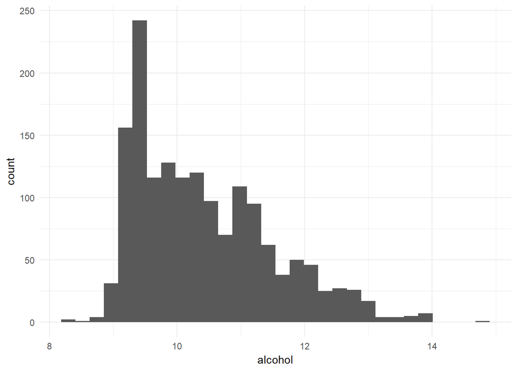

What I find most interesting about this initial plot is that the distribution has a skew to the right. Living in Australia I’m used to quite bold red wines, in particular Shiraz. In doing a little research I found a quote from James Halliday, a renowned wine expert.

> *“For the sake of simplicity, the alcohol of any red wine in excess of 14.5% (alcohol by volume) can be said to be high. As recently as the 1980s, the benchmark was 13.5%. Ten years earlier, it might have been 12.5%.”* **James Halliday**

Note that we only have 91 wines above the old standard, and just 1 above the more recent definition. This confirms that these are quite different from the new world wines that I tend to enjoy. It might be worth adding some indicators to split by these strength boundaries for later analysis.

Let’s get on with it and create histograms for the other variables.

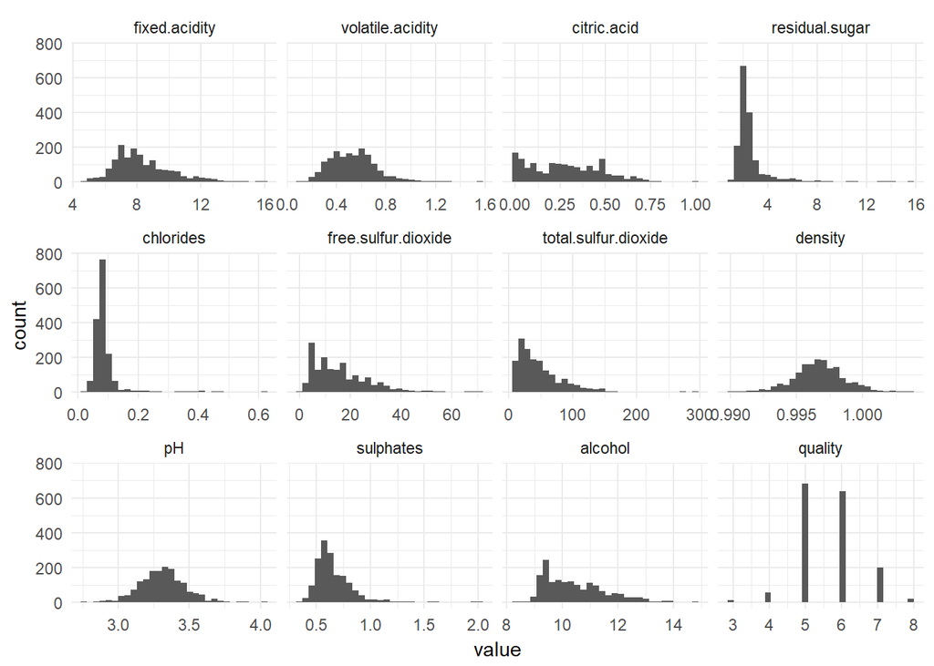

As expected the scale for quality follows a roughly normal distribution. The rough facet diagram is too granular, but we’ll re-render it below.

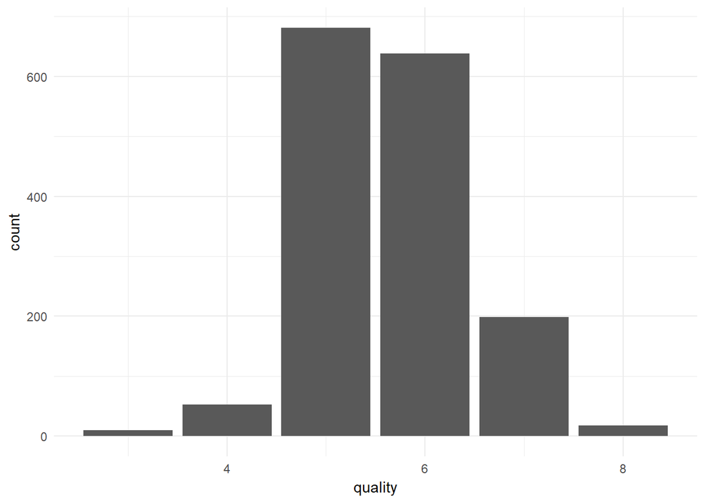

## Bivariate Plots Section

In this section I’m mostly interested in observing the relationship between quality. But before exploring that in detail, let’s look at the relationships between all the variables. Typically, I would start by looking at correlations and then expand this to scatter plots of all pairs of variables.

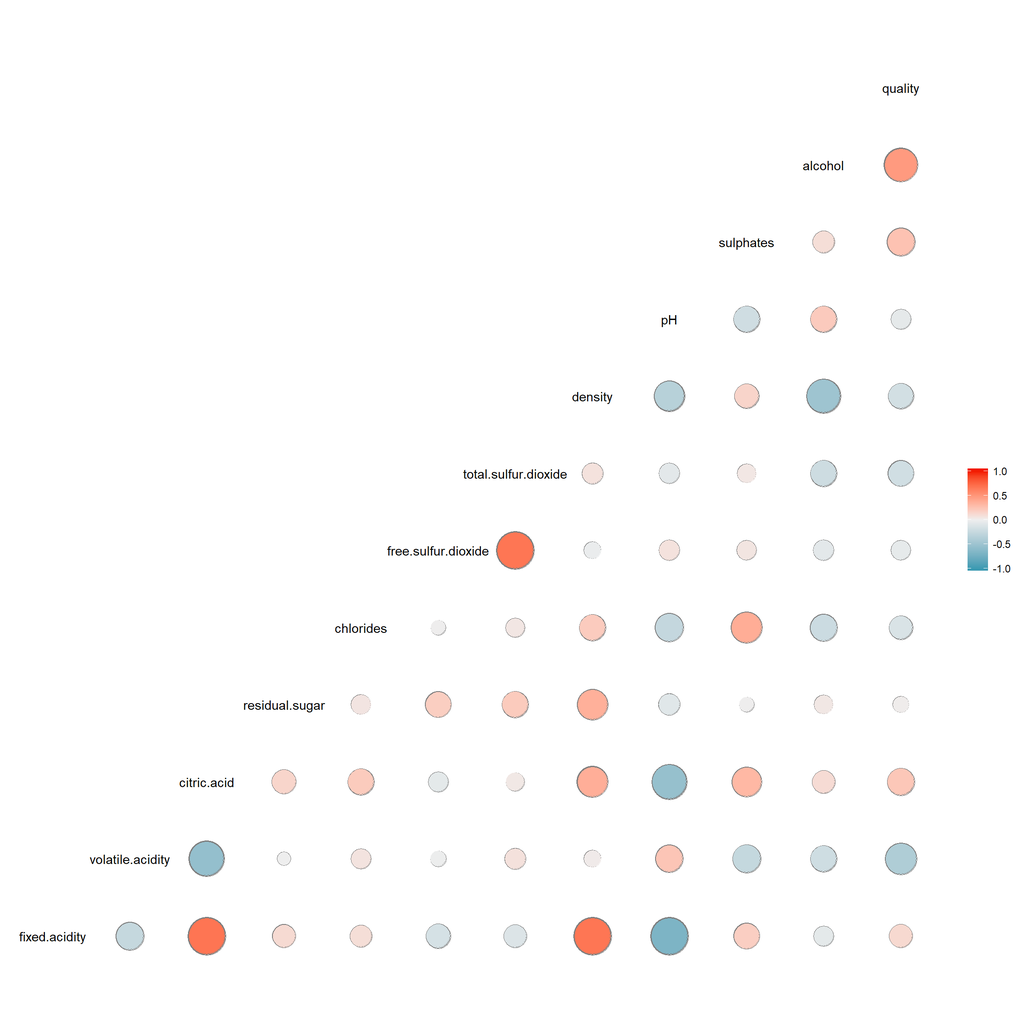

Our strongest correlation with quality is the amount of alcohol, perhaps our judges were from the Barossa Valley! The level of citric acids and sulphates seems to have a moderate correlation, and we can see that having a large amount of volatile acid can also annoy judges. This shouldn’t come as a surprise, as this tends to be what can give wine a vinegar taste.

We’ll plot all the scatters to see if anything jumps out, however given the number of variables it may be tricky to read the plots and we’ll have to generate ones that look interesting and take a closer look later.

From this point on I’ll be considering quality as a categorical variable, whilst it’s been useful to calculate correlations; for multivariate plotting treating it as a factor should yield more insight.

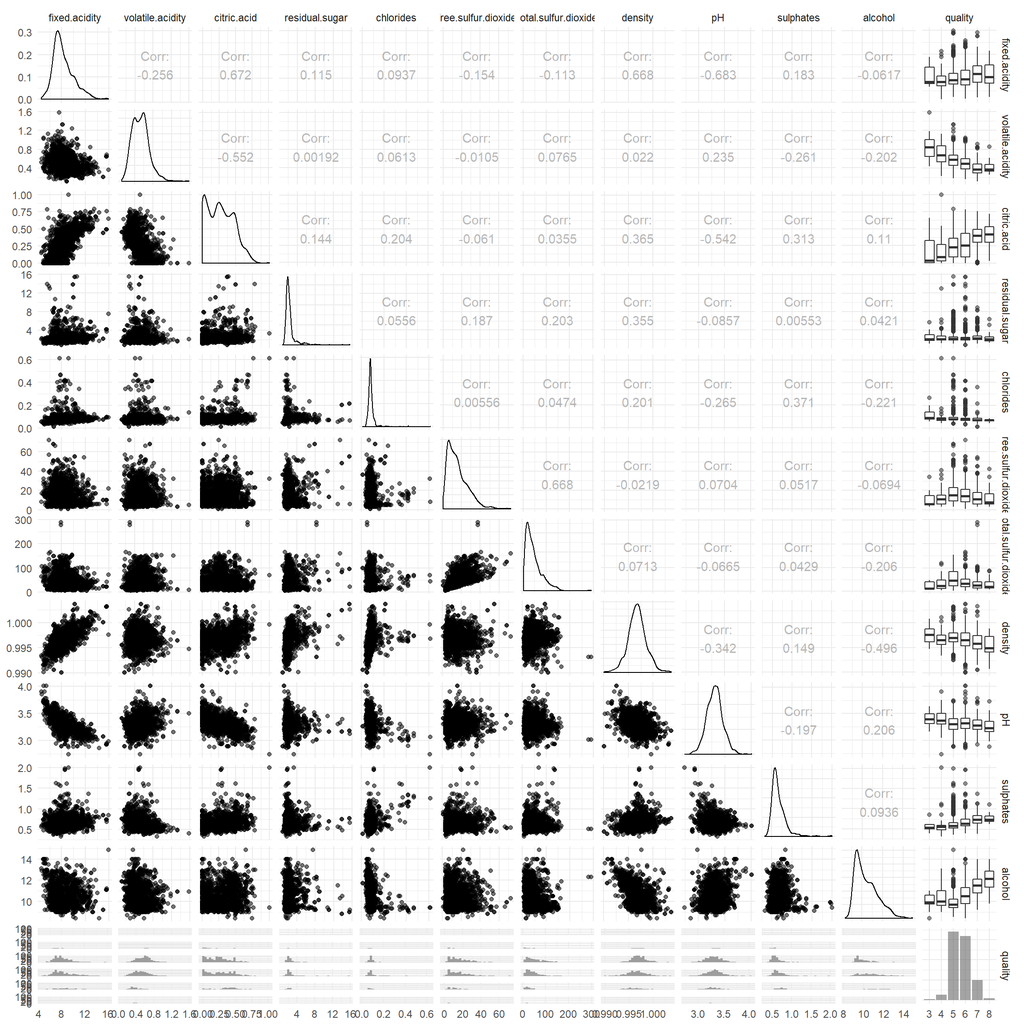

Let’s explore some of the highly correlated variables in more detail.

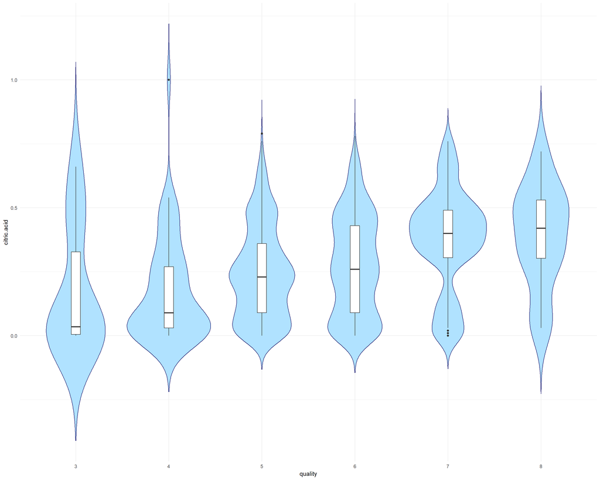

This first violin plot reconfirms that better rated wines tend to have a higher concentration of citric acid. In the notes provided it states that this provides a freshness and flavour to the wine. A little further research shows that citric acid can be unstable and can ferment into acetic acid which is highly undesirable. Let’s have a look at the relationship between citric acid and see if the antimicrobial effect limits this risk. We had seen a positive correlation, but let’s explore further.

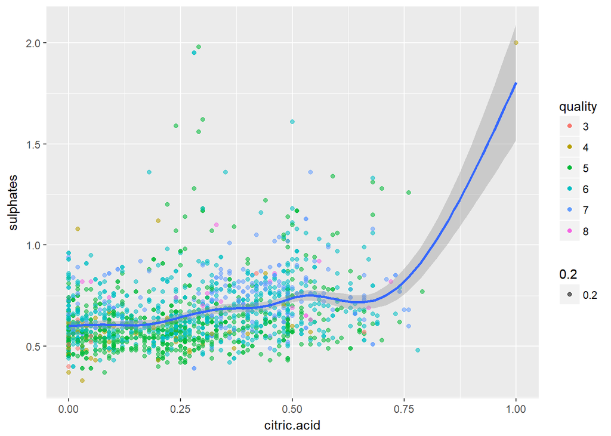

The default model applied here is a little misleading given what looks like an erroneous data point at (1,2). Let’s try again, this time removing the outlier. We’ll also adjust the zoom a little to take a closer look at the trend without removing more of the data.

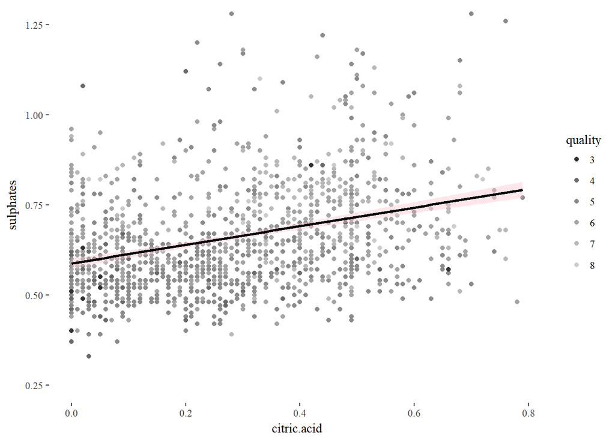

This does still give us a positive trend, but it’s not as significant as we might have hoped. What we can see is that the quality increases with each variable. Let’s look at the sulphates

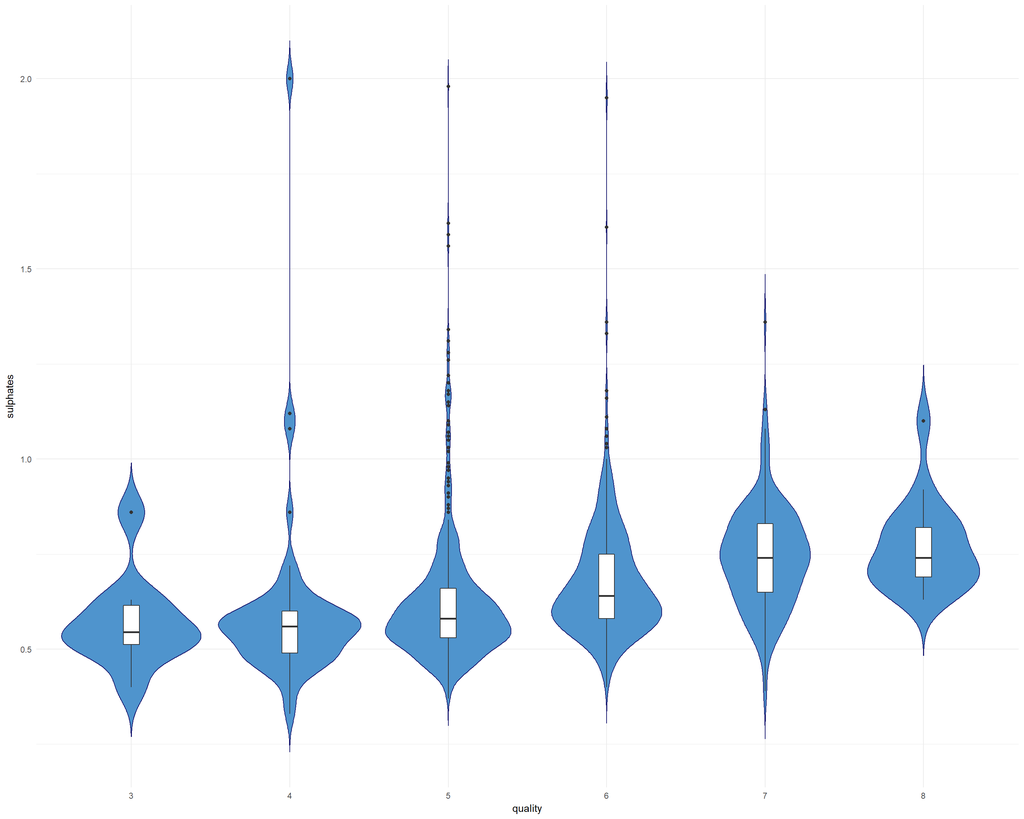

We see a similar trend again with a gradual increase in median values as we go up the quality grades. These plots show that the sulphates have less volatility than the amount of citric acid in each category, and glancing back at our first histogram plots we can see that it is a quite tight distribution with a standard deviation of 0.169507 g/dm^3. Sulphates had quite a strong positive correlation with chlorides. Let’s take a closer look.

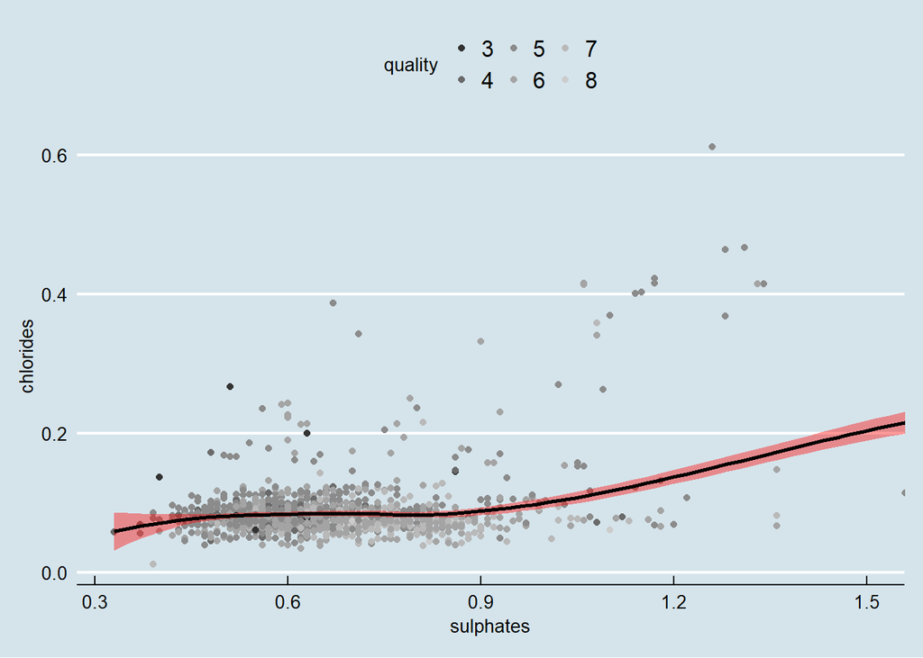

Using the loess model to try and tease out a trend, we don’t really find anything convincing and perhaps we should have stuck with a simple linear model. However, it doesn’t tell us much more than the correlation matrix.

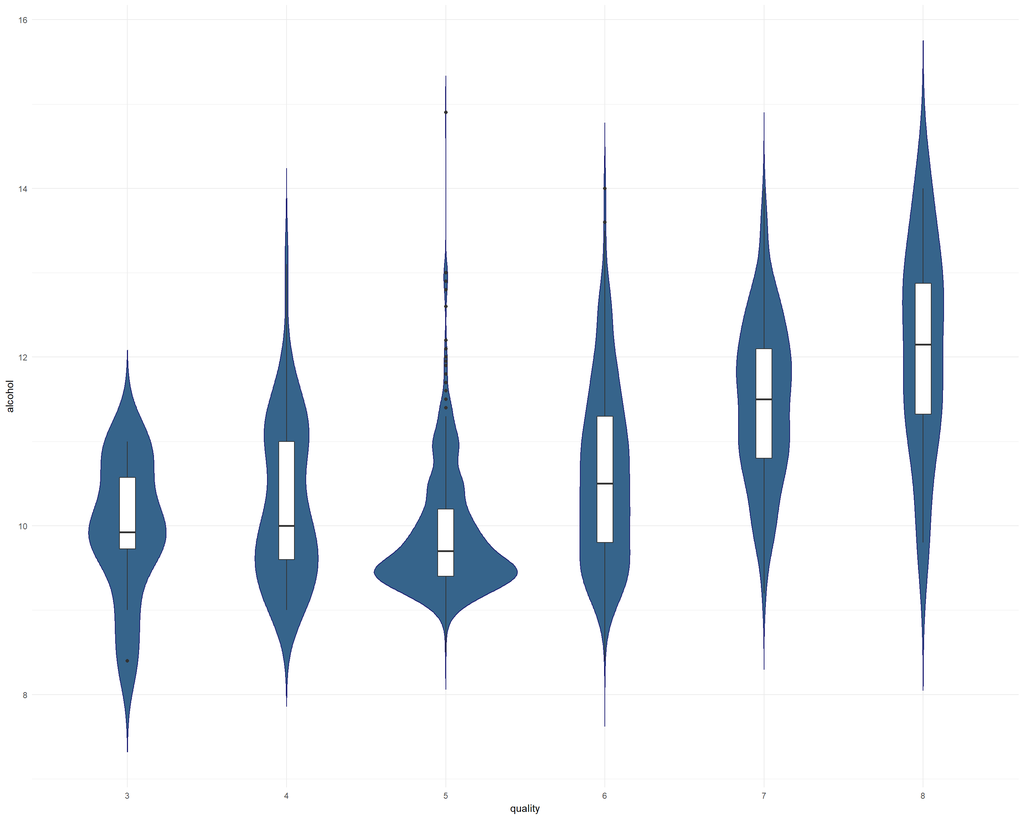

This plot is interesting, we had noted earlier that wines with higher alcohol content tended to get better scores, and whilst this is true, we can see that the standard deviation of alcohol content is different across the ratings.

| quality | al.stdDev | al.mean | al.median | al.n |
| --- | --- | --- | --- | --- |
| 3 | 0.8180091 | 9.955000 | 9.925 | 10 |
| 4 | 0.9347760 | 10.265094 | 10.000 | 53 |
| 5 | 0.7365210 | 9.899706 | 9.700 | 681 |
| 6 | 1.0496390 | 10.629519 | 10.500 | 638 |
| 7 | 0.9619330 | 11.465913 | 11.500 | 199 |
| 8 | 1.2240109 | 12.094444 | 12.150 | 18 |

## Multivariate Analysis

### Clusters

In this section we’re going to cluster the data and observe the frequency of ratings across the analytically derived clusters. Given R is new for me, I’m going to stick to simple clustering with using k-means and I’ll try a few values of K.

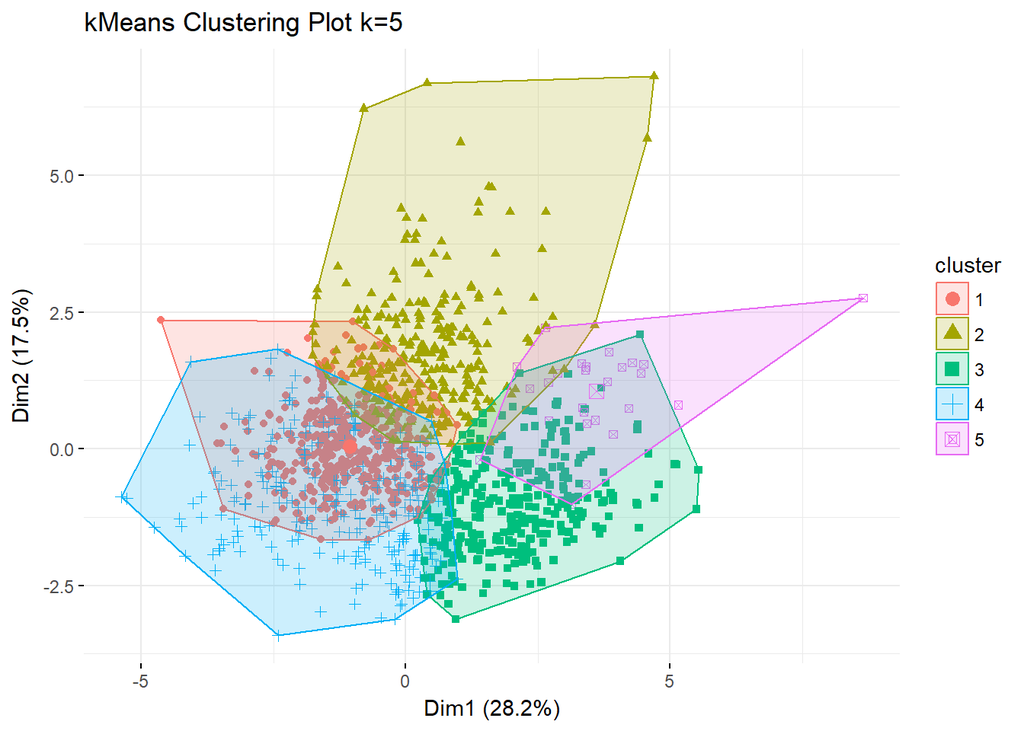

This gives us a good starting point, we can see the 5 clusters across the two primary dimensions that have been created through principal components analysis (PCA). Explaining PCA is beyond the scope of this exploration, however it is convenient for the presentation of multidimensional clusters.

The whilst the groups do show separation, I think we could do better.

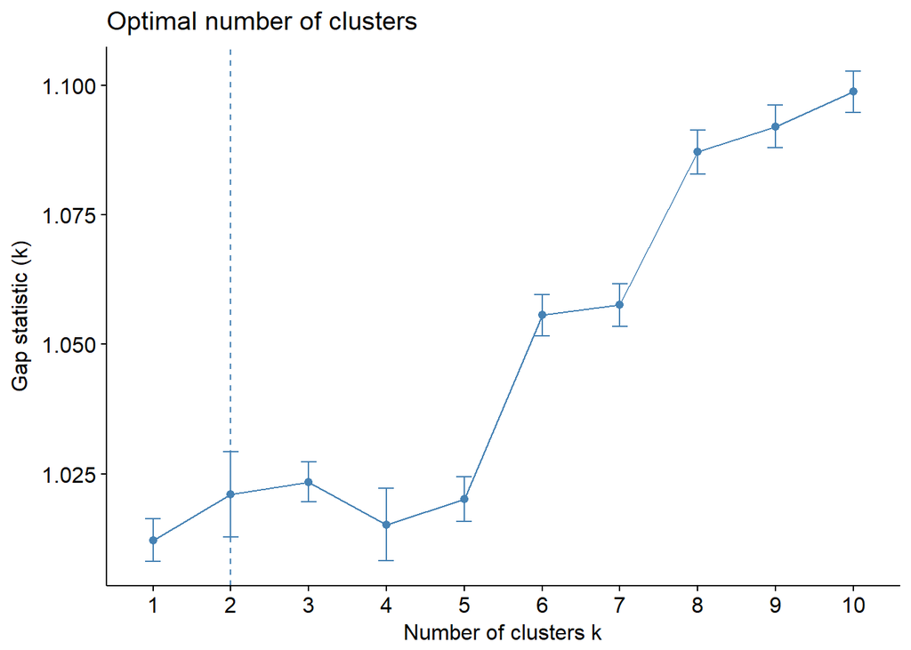

This tells us that to maximise the gap between our clusters we should produce a cluster diagram with 2 centroids. However, I think that having at least 3 would give us some more interesting talking points without sacrificing the statistics. Let’s look at the two cluster diagrams and make the call.

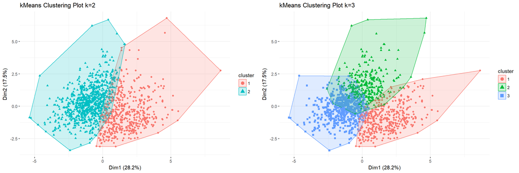

Whilst we have some overlap, I think we’re ok to go with 3 clusters to made our analysis a little more interesting. Let’s add our clusters to the data and look at whether is related to our clusters.

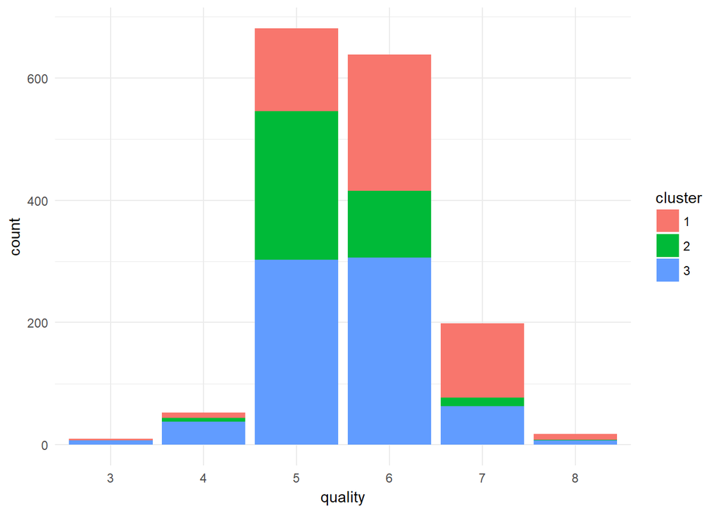

| cluster | qual.stdDev | qual.mean | qual.median | qual.n |
| --- | --- | --- | --- | --- |
| 1 | 0.8467422 | 3.960159 | 4 | 502 |
| 2 | 0.5953688 | 3.359249 | 3 | 373 |
| 3 | 0.8018816 | 3.553867 | 4 | 724 |

It looks like we have a drift away from wines in cluster 2 and towards those in cluster 1. By changing the visualisation to represent proportions we can take a closer look.

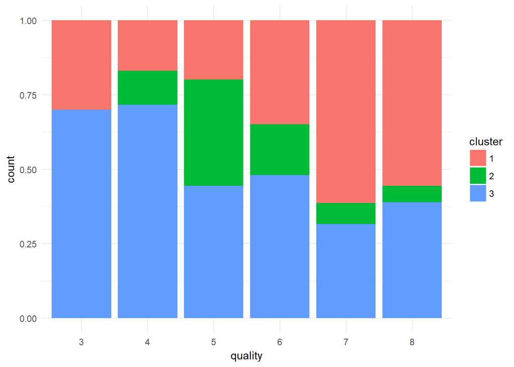

This has made the relationship a little clearer, however the question that springs to mind is, “ae the differences in proportion statistically significant?”. Whilst we could model this with t-Tests or (even better) include our clusters in a regression model to understand the importance, I fell that this is where our exploration will end for now. Time to wrap up!

## Final Plots and Summary

To summarise the findings, I’d like to showcase 3 plots. Firstly, the correlation matrix. I find this a hugely useful tool to declutter data, particularly finding variables that may be equivalent or highly dependent. In this analysis it was primarily used to flag variables that seemed to linearly influence the judges score.

### Plot One: Correlation Matrix

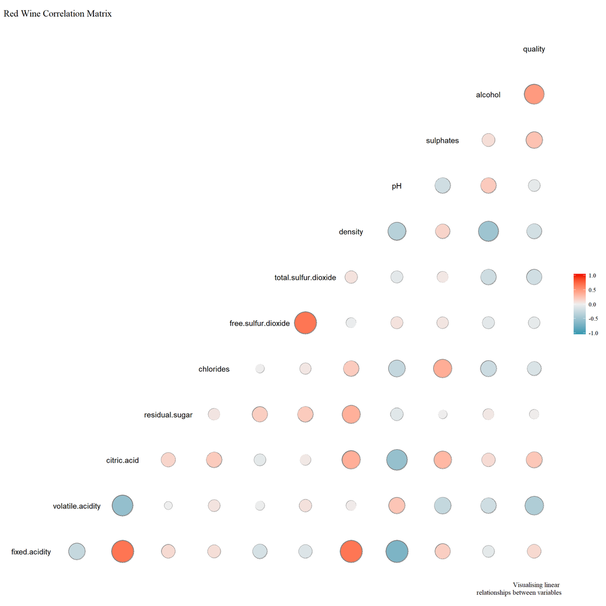

### Description One

At a glance this plot tells us that alcohol, sulphates and citric acid are correlated with the judges’ quality score. This makes sense. Our domain knowledge and external research tells us that alcohol and citric acids can alter the bouquet and hence the taste. Sulphates act as a control preventing chemical reactions that can impair the wine.

### Plot Two: Violin plot of Alcohol distribution by quality

[figure not shown]

### Description Two

The main reason that I like this plot is that it can convey a lot of information to an analyst quickly. Only by overlaying the distribution did it become apparent that the standard deviation of alcohol in highly rated wines was so broad, meaning that alcohol content alone cannot be considered to be a causal factor (which would not be the case if I were a judge, I’m sure.)

### Plot Three: Clusters

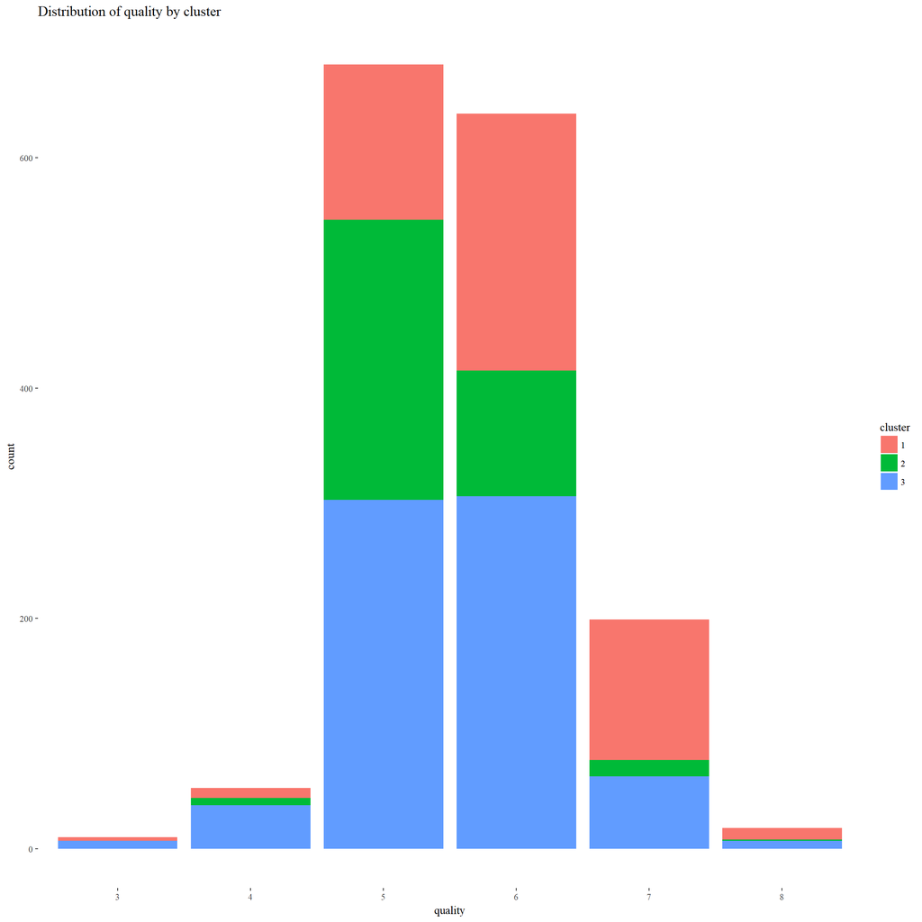

### Description Three

I’ve chosen this stacked bar chart as my final observation as I think it can act as a stepping stone for the next phase of analysis, whether that be refining the number of clusters (you get some interesting results using k=5), performing inference tests or including the variable in a regression model to try to predict quality ratings.

## Reflection

This dataset was incredibly tidy and easy to perform standard analysis, a perfect playground for learning a new language. I had hoped to learn more about red wines in the analysis, but unfortunately without more context it has done little to enlighten my next visit to the bottle shop. However, I have learnt a lot about the science of wine making, and the chemical reactions to aim for and avoid when crafting a palatable wine.

The cluster analysis hints at what are essentially similar chemical profiles. With some further detail an analyst might be able to infer other properties about the wine, such as the region, age or vintage, varieties of grape and perhaps even more revealing characteristics about the process of making the wine. The reader should note that I haven’t carried out a regression analysis to predict quality as a matter of principle; personally, I feel that wine is to be enjoyed rather than judged.

### A parting quote:

> *“Wine can of their wits the wise beguile, Make the sage frolic, and the serious smile”* **Homer**

But what does it do to the Data Analyst…?

Thank you for your time.

Guy